# Midlife crisis - Data Analysis

Ingo Rohlfing

## Loading packages

Loading packages for data analysis.

```r
library(devtools) # session info
library(dplyr) # data wrangling
library(formattable) # nicer summary tables
library(ggplot2) # plotting
library(lfe) # fixed-effects regression
library(sjPlot) # regression tables and Word export
library(texreg) # regression table export to LaTeX
library(xtable) # table export to LaTeX
```

**Note:** The execution of this script requires that `data_processing.Rmd` is executed first.

## Country-level analysis

Loading preprocessed country data.

```r
country_level <- readRDS(file = "../Data/AnalysisData/country_level.rds")
```

Descriptive table of countries.

```r
country_level %>%
  mutate(across(c(cm_satis, inc, exp),
                ~ round(.x, digits = 2))) %>%
  # assign informative variable labels
  rename(`Mean satisfaction` = cm_satis,
         Income = inc,
         Expenditure = exp) %>%
  select(-country) -> country_tab
formattable(country_tab)
```

| Country name | Mean satisfaction | Income | Expenditure |
| --- | --- | --- | --- |
| China | 5.17 | 1135.45 | 15.59 |
| India | 5.09 | 486.64 | 11.89 |
| Indonesia | 5.76 | 909.89 | 7.26 |
| Jordan | 5.34 | 1901.58 | 22.70 |
| Pakistan | 5.47 | 483.03 | 8.72 |
| Russian Federation | 4.74 | 2375.16 | 17.95 |
| United States | 7.02 | 38175.38 | 15.04 |

Scatterplot of mean satisfaction against GDP.

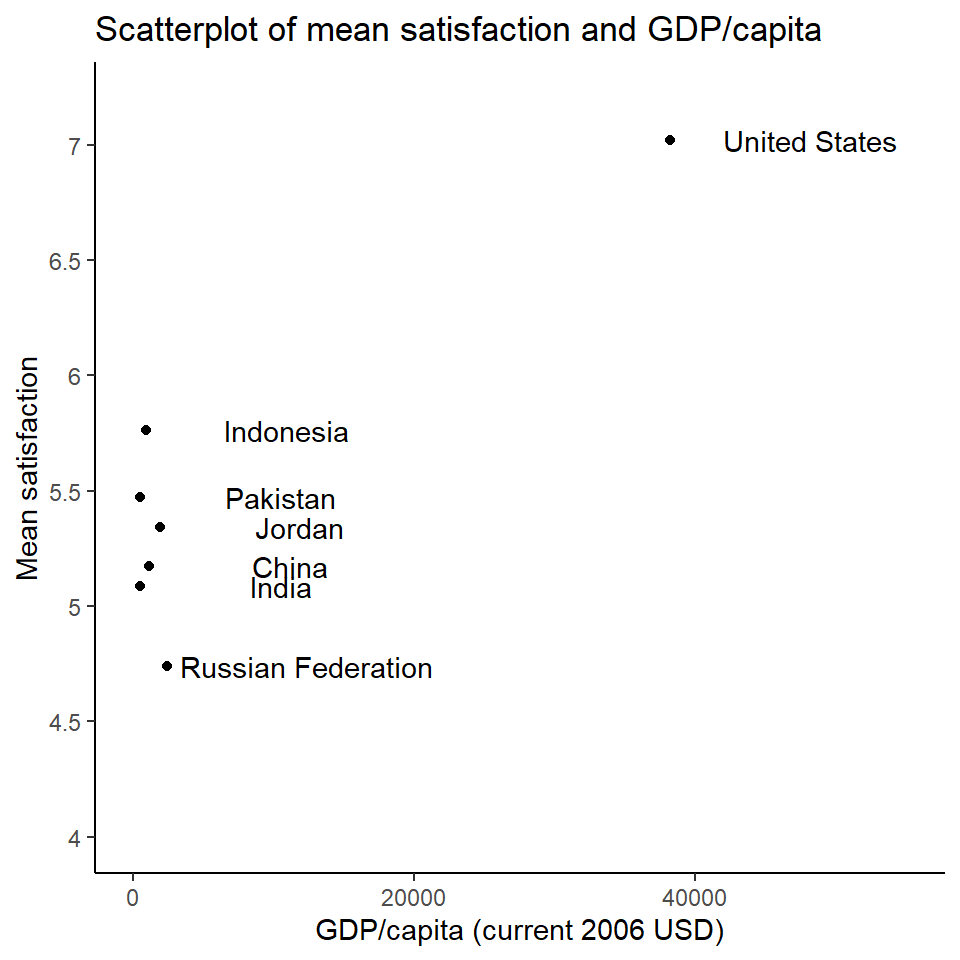

```r
ggplot(data = country_level) +
  geom_point(mapping = aes(x = inc, y = cm_satis)) +
  geom_text(mapping = aes(x = inc, y = cm_satis, label = `Country name`),
             nudge_x = 10000) +
  ggtitle("Scatterplot of mean satisfaction and GDP/capita") +
  scale_x_continuous("GDP/capita (current 2006 USD)",
                     limits = c(0, 55000)) +
  scale_y_continuous("Mean satisfaction",
                     limits = c(4, 7.2),
                     breaks = seq(4, 7, by = 0.5),
                     labels = seq(4, 7, by = 0.5)) +
  theme_classic()
```

## Individual-level analysis

Loading individual-level data.

```r
individual_level <- readRDS(file = "../Data/AnalysisData/individual_level.rds")
```

OLS regression of satisfaction on age and $age^2$.

```r
# estimate model
ind_ols <- lm(satis ~ age + age2, data = individual_level)
# produce regression table
tab_model(ind_ols,
          digits = 4, show.se = TRUE,
          dv.labels = "Satisfaction with life (OLS)",
          pred.labels = c("Intercept", "Age", "Age squared"))
```

|  | Satisfaction with life (OLS) |  |  |  |
| --- | --- | --- | --- | --- |
| Predictors | Estimates | std. Error | CI | p |
| Intercept | 6.8685 | 0.2279 | 6.4217 – 7.3153 | **<0.001** |
| Age | -0.0653 | 0.0114 | -0.0877 – -0.0429 | **<0.001** |
| Age squared | 0.0007 | 0.0001 | 0.0004 – 0.0009 | **<0.001** |
| Observations | 10355 |  |  |  |
| R<sup>2</sup> / R<sup>2</sup> adjusted | 0.004 / 0.004 |  |  |  |

OLS regression of satisfaction on age and age squared with country fixed-effects.

```r
# estimate model
ind_fe <- felm(satis ~ age + age2 | country, data = individual_level)
# show regression output
tab_model(ind_fe,
          show.se = TRUE, digits = 4, digits.p = 4,
          dv.labels = "Satisfaction with life (country FE suppressed)",
          pred.labels = c("Age", "Age squared"))
```

|  | Satisfaction with life (country FE suppressed) |  |  |  |
| --- | --- | --- | --- | --- |
| Predictors | Estimates | std. Error | CI | p |
| Age | -0.0550 | 0.0112 | -0.0770 – -0.0330 | **<0.001** |
| Age squared | 0.0005 | 0.0001 | 0.0003 – 0.0008 | **0.0001** |
| N <sub>country</sub> | 7 |  |  |  |
| Observations | 10355 |  |  |  |

## Software references

Dahl, David B., David Scott, Charles Roosen, Arni Magnussonm Jonathan Swinton. 2019. *xtable: Export Tables to LaTeX or HTML.*  
https://CRAN.R-project.org/package=xtable

Gaure, S. 2021. *lfe: Linear group fixed effects.* https://cran.r-project.org/web/packages/lfe/

Leifeld, Philip. 2013). *texreg: Conversion of Statistical Model Output in R to LaTeX and HTML Tables.* Journal of Statistical Software, 55(8), 1-24.  
http://dx.doi.org/10.18637/jss.v055.i08

Lüdecke, D. 2021. *sjPlot: Data Visualization for Statistics in Social Science.* https://CRAN.R-project.org/package=sjPlot

Rodríguez-Sánchez, Francisco, Shaurita D. Hutchins. 2020.  
*grateful: Facilitate citation of R packages.*  
https://github.com/Pakillo/grateful.

R Core Team. 2020. *R: A Language and Environment for Statistical Computing*. Vienna, Austria: R Foundation for Statistical Computing. https://www.R-project.org/.

Ren, Kun, Kenton Russell. 2016). *formattable: Create ‘Formattable’ Data Structures.* https://CRAN.R-project.org/package=formattable

RStudio Team. 2021. *RStudio: Integrated Development Environment for R.*  
RStudio, PBC, Boston, MA. http://www.rstudio.com/.

Wickham, Hadley, Romain François, Lionel Henry, and Kirill Müller. 2021. *dplyr: A Grammar of Data Manipulation*. https://CRAN.R-project.org/package=dplyr.

Wickham, Hadley, Jim Hester, and Winston Chang. 2020. *devtools: Tools to Make Developing R Packages Easier*. https://CRAN.R-project.org/package=devtools